# Sentinela

Radar semanal de risco de asteroides · CRISP-DM + LLM

Trabalho Final — AI Applications (MBA)

## O problema

A NASA cataloga **dezenas de asteroides por semana** passando perto da Terra.

- **Quem decide:** curadoria/comunicação de um planetário, museu de ciências ou jornalismo científico — e qualquer núcleo de risco de baixa probabilidade e alto impacto.
- **A decisão da semana:** o que destacar, comunicar ou escalar (pauta, post, nota, alerta).
- **Hoje:** exige um especialista lendo um feed técnico da NASA — ou não é feita, e o relevante passa batido enquanto o trivial vira alarme falso.

**A pergunta real:** *o que merece atenção esta semana?*

## A solução — um pipeline, não um chat

| Etapa | O que faz |
| --- | --- |
| **Coleta** | NASA NeoWs (API pública) → dados da semana |
| **Baseline** | score físico de risco (tamanho, velocidade, distância) |
| **LLM** | GPT com **saída estruturada** (Pydantic) → resumo executivo |
| **Avaliação** | 3 camadas (vs. NASA, concordância, regra de ouro) |
| **Entrega** | WhatsApp automático, agendado no GitHub Actions |

Metodologia **CRISP-DM**, dirigindo o **Claude Code**. Regra de ouro: nenhum número inventado.

## O resultado desta semana

- **32 asteroides** monitorados · **4** perigosos (NASA)
- Maior objeto: **1013 m** · passagem mais próxima: **18** distâncias lunares
- Baseline vs. flag oficial da NASA: **Recall 100%** · **AUC 0.86**

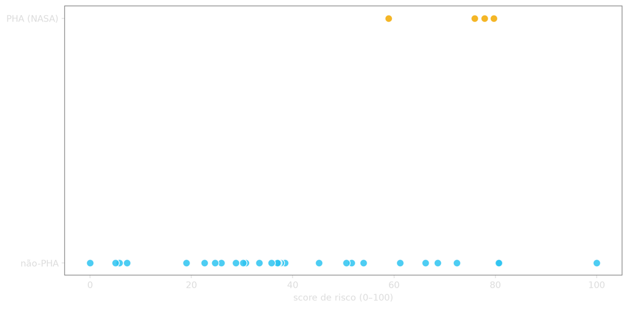

## O valor

- **Substitui trabalho especializado**: troca horas de leitura de um feed técnico por um digest de **custo marginal ~zero** (centavos de tokens por semana).
- **Recall 100%** → nenhum objeto perigoso da NASA escapa do radar semanal.
- **Honestidade avaliativa**: sabemos *onde* o baseline acerta (triar) e *onde* não se propõe a acertar (o critério orbital da NASA).
- **Automático**: chega sozinho no WhatsApp toda semana — zero intervenção.
- **Reaproveitável**: troque a fonte e o prompt, e o mesmo esqueleto serve a outro setor (indicadores, tickets, contratos).

## Próximos passos & fechamento

**v2.0:** escala de Torino + probabilidade de impacto (Sentry); calibração multi-semana; comparar provedores de LLM (custo × fidelidade).

> A disciplina numa frase: **dirigir um agente para transformar um problema de negócio em um produto reprodutível e automatizado.**

**Obrigado.** · Código: repositório GitHub · Dados: NASA NeoWs